[O’Hara on GitHub](https://github.com/oharac)

# Sensitivity of MPA rasters to MPA size

Compiled on Fri Apr 5 14:40:55 2019 by ohara

To calculate marine protected area global distribution, we rasterized vector spatial data (polygon features) from the World Database on Protected Areas [WDPA, @iucn_2018a] to eliminate double-counting due to overlapping protected areas. However, while rasterization enables convenient comparison of spatial data, it necessarily loses some information particularly when the resolution of the raster is significantly larger than the scale of polygon features. Our primary analysis of marine biodiversity risk was assessed at cells of 100 km<sup>2</sup>; however, many marine protected areas are far smaller than this size, so for MPA coverage, we chose a finer resolution, 1 km<sup>2</sup>, to calculate proportional coverage within each larger analysis cell. To assess the ability of this scale to capture the vast majority of MPAs relevant to the status of global marine biodiversity, we focused on three questions:

- How many small MPAs exist that are at or below the resolution of the 1 km<sup>2</sup> raster resolution, and to what extent does the total area of these MPAs contribute to the global MPA estate?
- How significant is the result of small MPAs potentially dropped by the rasterization process, i.e., total number, proportional count, and proportion of total protected area of MPAs not included in the raster output?
- How closely does the resulting MPA raster output reflect the protected area indicated by the MPA polygons input?

### Small MPA coverage as a proportion of global MPA estate

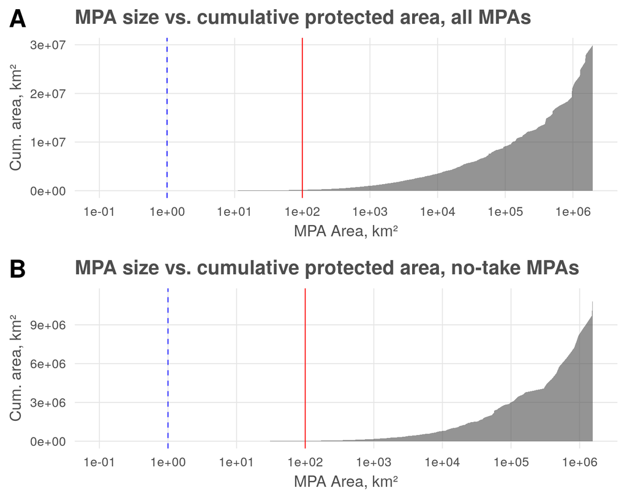

> Figure SM2: Contribution of protected area of different sizes to the cumulative global MPA estate, based on original WDPA polygon data. A) all protection categories are included. B) only no-take marine protected areas are included. The red solid line indicates MPA size 100 km<sup>2</sup>, i.e., the resolution of the biodiversity risk data; the blue dashed line indicates MPA size 1 km<sup>2</sup>, i.e., the resolution of the MPA rasterization process. Note that overlapping polygons are not resolved and result in some double-counting.

Figure SM2 shows that the proportion of MPA coverage from small MPAs (< 1 km<sup>2</sup> and < 100 km<sup>2</sup>) is miniscule.

Table SM1: All protected areas

| MPA size | A total, km² | N | % total area |
| --- | --- | --- | --- |
| < 1 km^2 | 1513.703 | 5677 | 0.0050580 |
| < 100 km^2 | 162141.387 | 8737 | 0.5417953 |
| < 1000 km^2 | 852239.779 | 2447 | 2.8477586 |
| >= 1000 km^2 | 28910791.811 | 1074 | 96.6053881 |

Table SM1 shows that when examining all MPAs ($n$ = 17,935), there are more than 14,000 MPAs smaller than 100 km<sup>2</sup>, comprising a total area of only 0.55% of all marine protection of any category; MPAs smaller than 1 km<sup>2</sup> (including as small as 5.0 m<sup>2</sup>) comprise only 0.005% of all marine protection. There are more than 3,500 MPAs larger than 100 km<sup>2</sup>, which encompass 99.45% of all marine protection.

Table SM2: No-take protection only

| MPA size | A total, km² | N | % total area |
| --- | --- | --- | --- |
| < 1 km^2 | 339.231 | 1287 | 0.0030129 |
| < 100 km^2 | 24461.060 | 1356 | 0.2172490 |
| < 1000 km^2 | 144854.132 | 409 | 1.2865108 |
| >= 1000 km^2 | 11089803.108 | 278 | 98.4932274 |

The pattern is even more pronounced for no-take MPAs ($n$ = 3,330, Table SM2) than for the entire collection of MPAs regardless of category: no-take MPAs smaller than 100 km<sup>2</sup> contribute only 0.22% of the global no-take MPA estate, while those smaller than 1 km<sup>2</sup> contribute only 0.003%.

### Effect of rasterization on inclusion of small MPAs

To facilitate comparison between polygon area calculations and raster area calculations, we created a representative sample polygon dataset. This dataset included only no-take MPAs (i.e., IUCN category I or II or designated no-take area greater than 75% of the total area). To eliminate double-counting of protected area, these no-take MPA features were filtered to remove overlapping polygons; since our concern is the effects of rasterization on small MPAs, we removed the larger of any pair of overlapping polygons, resulting in 2,862 distinct no-take MPA features. While this dataset differs from that used above and in the primary analysis of the manuscript, it is a representative sample for the sake of testing the effects of the rasterization process on inclusion and total area.

### Area difference by size class

Difference in area calculated as $\sum(A_{polygon} - A_{raster})$. Negative differences and positive differences may offset each other; the aggregate is the real total difference in MPA coverage.

Table SM3: Total difference in area by size class

| Size class | N | Area in class, km² | Cells in class | ∆ Area, km² | Cum ∆ Area, km² | Cum ∆ Area, % |
| --- | --- | --- | --- | --- | --- | --- |
| < .001 | 7 | 4.449600e-03 | 0 | 0.0044 | 0.0044 | 0.0000001 |
| < .01 | 41 | 2.164264e-01 | 0 | 0.2164 | 0.2208 | 0.0000033 |
| < .1 | 425 | 2.013718e+01 | 19 | 1.1372 | 1.3580 | 0.0000200 |
| < 1 | 756 | 2.956252e+02 | 303 | -7.3748 | -6.0168 | -0.0000887 |
| < 3 | 350 | 6.200887e+02 | 630 | -9.9113 | -15.9281 | -0.0002349 |
| < 10 | 326 | 1.945573e+03 | 1909 | 36.5731 | 20.6450 | 0.0003045 |
| >= 10 | 957 | 6.777344e+06 | 6786496 | -9152.3860 | -9131.7410 | -0.1346820 |

Table SM3: Total difference in area by size class at 500m

| Size class | N | Area in class, km² | Cells in class | ∆ Area, km² | Cum ∆ Area, km² | Cum ∆ Area, % |
| --- | --- | --- | --- | --- | --- | --- |
| < .001 | 7 | 4.449600e-03 | 0.00 | 0.0044 | 0.0044 | 0.0000001 |
| < .01 | 41 | 2.164264e-01 | 0.25 | -0.0336 | -0.0292 | -0.0000004 |
| < .1 | 425 | 2.013718e+01 | 21.75 | -1.6128 | -1.6420 | -0.0000242 |
| < 1 | 756 | 2.956252e+02 | 296.25 | -0.6248 | -2.2668 | -0.0000334 |
| < 3 | 350 | 6.200887e+02 | 628.00 | -7.9113 | -10.1781 | -0.0001501 |
| < 10 | 326 | 1.945573e+03 | 1932.50 | 13.0731 | 2.8950 | 0.0000427 |
| >= 10 | 957 | 6.777344e+06 | 6787394.00 | -10050.3860 | -10047.4910 | -0.1481882 |

Table SM3 shows that the rasterization process results in a total calculated area that differs from the original dataset by only 0.13%, when positive and negative errors are allowed to balance out.

### Absolute area difference by size class

Difference in area calculated as $\sum|A_{polygon} - A_{raster}|$. Negative differences and positive differences are both penalized, resulting in a more conservative estimate of the differences.

Table SM4: Total absolute difference in area by size class

| Size class | N | Area in class, km² | Cells in class | ∆ Area, absolute, km² | Cum ∆ Area, km² | Cum ∆ Area, % |
| --- | --- | --- | --- | --- | --- | --- |
| < .001 | 7 | 4.449600e-03 | 0 | 0.0044 | 0.0044 | 0.0000001 |
| < .01 | 41 | 2.164264e-01 | 0 | 0.2164 | 0.2208 | 0.0000033 |
| < .1 | 425 | 2.013718e+01 | 19 | 37.0636 | 37.2844 | 0.0005499 |
| < 1 | 756 | 2.956252e+02 | 303 | 320.8607 | 358.1451 | 0.0052822 |
| < 3 | 350 | 6.200887e+02 | 630 | 245.1543 | 603.2994 | 0.0088979 |
| < 10 | 326 | 1.945573e+03 | 1909 | 332.4051 | 935.7045 | 0.0138005 |
| >= 10 | 957 | 6.777344e+06 | 6786496 | 23651.3135 | 24587.0180 | 0.3626283 |

Table SM4: Total absolute difference in area by size class 500m

| Size class | N | Area in class, km² | Cells in class | ∆ Area, absolute, km² | Cum ∆ Area, km² | Cum ∆ Area, % |
| --- | --- | --- | --- | --- | --- | --- |
| < .001 | 7 | 4.449600e-03 | 0.00 | 0.0044 | 0.0044 | 0.0000001 |
| < .01 | 41 | 2.164264e-01 | 0.25 | 0.4593 | 0.4637 | 0.0000068 |
| < .1 | 425 | 2.013718e+01 | 21.75 | 31.7840 | 32.2477 | 0.0004756 |
| < 1 | 756 | 2.956252e+02 | 296.25 | 122.4682 | 154.7159 | 0.0022819 |
| < 3 | 350 | 6.200887e+02 | 628.00 | 92.4465 | 247.1624 | 0.0036453 |
| < 10 | 326 | 1.945573e+03 | 1932.50 | 129.3065 | 376.4689 | 0.0055525 |
| >= 10 | 957 | 6.777344e+06 | 6787394.00 | 18820.7204 | 19197.1893 | 0.2831350 |

Table SM4 shows that if high and low errors due to rasterization are counted as a positive difference, then the rasterization process results in a total error of 0.36% relative to the original dataset.

### Number of MPAs dropped due to rasterization

MPA presence within a cell is determined by the overlap of the MPA polygon and the center of the cell. For very small MPAs, or MPAs with narrow aspect ratios, the polygon may not overlap the center, and thus may not be counted.

Table SM5: Dropped MPAs by size class

| Size class | N | Area in class, km² | N dropped | Drop rate, % | Area dropped, km² | Area dropped, % | Cum area dropped, km² | Cum area dropped, % |
| --- | --- | --- | --- | --- | --- | --- | --- | --- |
| < .001 | 7 | 4.449600e-03 | 7 | 100.00 | 0.0044 | 98.88 | 0.0044 | 0.0000001 |
| < .01 | 41 | 2.164264e-01 | 35 | 85.37 | 0.1870 | 86.40 | 0.1914 | 0.0000028 |
| < .1 | 425 | 2.013718e+01 | 352 | 82.82 | 16.1505 | 80.20 | 16.3419 | 0.0002410 |
| < 1 | 756 | 2.956252e+02 | 429 | 56.75 | 138.8538 | 46.97 | 155.1957 | 0.0022889 |
| < 3 | 350 | 6.200887e+02 | 32 | 9.14 | 43.4496 | 7.01 | 198.6453 | 0.0029298 |
| < 10 | 326 | 1.945573e+03 | 0 | 0.00 | 0.0000 | 0.00 | 198.6453 | 0.0029298 |
| >= 10 | 957 | 6.777344e+06 | 0 | 0.00 | 0.0000 | 0.00 | 198.6453 | 0.0029298 |

Table SM5: Dropped MPAs by size class 500m

| Size class | N | Area in class, km² | N dropped | Drop rate, % | Area dropped, km² | Area dropped, % | Cum area dropped, km² | Cum area dropped, % |
| --- | --- | --- | --- | --- | --- | --- | --- | --- |
| < .001 | 7 | 4.449600e-03 | 7 | 100.00 | 0.0044 | 98.88 | 0.0044 | 0.0000001 |
| < .01 | 41 | 2.164264e-01 | 34 | 82.93 | 0.1834 | 84.74 | 0.1878 | 0.0000028 |
| < .1 | 425 | 2.013718e+01 | 295 | 69.41 | 12.6786 | 62.96 | 12.8664 | 0.0001898 |
| < 1 | 756 | 2.956252e+02 | 130 | 17.20 | 26.0777 | 8.82 | 38.9441 | 0.0005744 |
| < 3 | 350 | 6.200887e+02 | 0 | 0.00 | 0.0000 | 0.00 | 38.9441 | 0.0005744 |
| < 10 | 326 | 1.945573e+03 | 0 | 0.00 | 0.0000 | 0.00 | 38.9441 | 0.0005744 |
| >= 10 | 957 | 6.777344e+06 | 0 | 0.00 | 0.0000 | 0.00 | 38.9441 | 0.0005744 |

Table SM5 shows that, indeed, many small MPAs are not included in the final raster. Unsurprisingly, the smaller the MPA, the more likely to be dropped. Dropped MPAs will result in a certain underestimate of MPA coverage globally. The total difference due to these dropped MPAs is 0.0029% of the MPA coverage of this sample dataset. This overestimates the loss, since many of these small MPAs would be overlapped by larger MPAs (and thus the area would be counted), and the sample dataset removes larger MPAs that would obscure them (and thus the total area of the sample dataset is biased low, inflating the relative proportion of dropped area).

## Explore effect of calculating to analysis raster resolution

To calculate protected area at the analysis scale, i.e. 100 km<sup>2</sup> cells, we count the proportion of protected cells at 1 km<sup>2</sup> that fall within each 100 km<sup>2</sup> cell, then divide by 100. We can then compare the sum of all cell areas to the total polygon area. The calculation is simple and lossless, thus the results are identical to the calculations using 1 km<sup>2</sup> cells.

Table SM6: Calculated protected area when scaling up to 100 km<sup>2</sup> analysis resolution

| Size class | Area in class, km² (100 km²) | Cum Area, km² (100 km²) | Area in class, km² (1 km²) | Cum Area, km² (1 km²) |
| --- | --- | --- | --- | --- |
| < .001 | 0 | 0 | 0 | 0 |
| < .01 | 0 | 0 | 0 | 0 |
| < .1 | 19 | 19 | 19 | 19 |
| < 1 | 303 | 322 | 303 | 322 |
| < 3 | 630 | 952 | 630 | 952 |
| < 10 | 1909 | 2861 | 1909 | 2861 |
| >= 10 | 6786496 | 6789357 | 6786496 | 6789357 |

Table SM6 shows that the result of aggregating these 1 km<sup>2</sup> cells to calculate the proportional protection of each cell at the 100 km<sup>2</sup> analysis resolution is identical to the analyses performed earlier at the finer 1 km<sup>2</sup> resolution. This part of the MPA rasterization process is lossless.